# Project 3: Visual Analysis of Youth Literacy Rates and Annual Percent of GDP Spent on Education

#### This html page, produced by creating an R markdown document, and using KnitR to knit the file into html. The purpose of this html file, is to show our analysis of two different data sets. One data set is the youth literacy rate by countries for various years. The other data set is the percentage of a countries GDP spent on education for various years. This html also shows the steps required to reproduce our findings, given the same data. Given the variables in both data sets, we were able to query the data base in a few different ways, join the data to gather results, and visualize them using ggplot2.

##### Rprofile.R:

An Rprofile.R document was created to include all of the packages required for the project, in order to avoid requiring packages in each of the R script files. Below is the call to the Rprofile document, and shows the necessary packages being loaded:

```r
source("../Rprofile.R", echo = FALSE)
```

```
##
##
##
##
## Registering fonts with R
```

#### Data:

Below is are the summary statistics for the data sets on Youth Literacy rate, and Annual percentage of GDP spent on education, as well as “head”, which displays the first 6 items in the data sets.

```r
source("../01 Data/Project3.R", echo = TRUE)
```

```
##
## > require("jsonlite")
##
## > require("RCurl")
##
## > YL <- data.frame(fromJSON(getURL(URLencode("129.152.144.84:5001/rest/native/?query=\"select * from youthlit\""),
## +     httpheader = c(DB = "jdbc:or ..." ... [TRUNCATED]
##
## > str(YL)
## 'data.frame':    3129 obs. of  6 variables:
##  $ REFERENCE_AREA      : Factor w/ 181 levels "Afghanistan",..: 25 25 25 25 26 26 26 26 26 26 ...
##  $ SEX                 : Factor w/ 3 levels "All genders",..: 1 1 3 2 2 3 1 1 3 2 ...
##  $ AGE_GROUP           : Factor w/ 1 level "15-24 year olds": 1 1 1 1 1 1 1 1 1 1 ...
##  $ UNITS_OF_MEASUREMENT: Factor w/ 1 level "Percent": 1 1 1 1 1 1 1 1 1 1 ...
##  $ TIME_PERIOD         : int  2004 1998 1998 1998 2010 2010 2010 2007 2007 2007 ...
##  $ OBSERVATION_VALUE   : num  83.4 76.3 81.8 71.1 76.4 ...
##
## > summary(YL)
##                              REFERENCE_AREA          SEX
##  MDG_Caucasus and Central Asia      :  87   All genders:1045
##  MDG_Developing regions             :  87   Female     :1042
##  MDG_Eastern Asia                   :  87   Male       :1042
##  MDG_Landlocked developing countries:  87
##  MDG_Latin America                  :  87
##  MDG_Latin America and the Caribbean:  87
##  (Other)                            :2607
##            AGE_GROUP    UNITS_OF_MEASUREMENT  TIME_PERIOD
##  15-24 year olds:3129   Percent:3129         Min.   :1975
##                                              1st Qu.:1993
##                                              Median :2002
##                                              Mean   :2000
##                                              3rd Qu.:2009
##                                              Max.   :2014
##
##  OBSERVATION_VALUE
##  Min.   :  6.664
##  1st Qu.: 77.345
##  Median : 93.502
##  Mean   : 86.068
##  3rd Qu.: 98.567
```

[output cut: 49 more lines]

```
## > head(PG)
##   REFERENCE_AREA            SEX      AGE_GROUP UNITS_OF_MEASUREMENT
## 1        Belgium Not applicable Not applicable              Percent
## 2        Belgium Not applicable Not applicable              Percent
## 3        Belgium Not applicable Not applicable              Percent
## 4        Belgium Not applicable Not applicable              Percent
## 5        Belgium Not applicable Not applicable              Percent
## 6        Belgium Not applicable Not applicable              Percent
##   TIME_PERIOD OBSERVATION_VALUE
## 1        2009            6.5681
## 2        2008            6.4311
## 3        2007            6.0040
## 4        2006            5.9838
## 5        2005            5.9220
## 6        2004            5.9550
```

#### Data Wrangling set 1 (Using inner-join):

```
##
## > require(tidyr)
##
## > require(dplyr)
##
## > require(ggplot2)
##
## > require(plyr)
```

```
##
## > Table1_df <- dplyr::inner_join(YL, PG, by = c("TIME_PERIOD",
## +     "REFERENCE_AREA"))
```

```
##
## > Plot1_df <- Table1_df %>% filter(TIME_PERIOD <= 2010,
## +     SEX.x != "All genders")
##
## > ggplot() + coord_cartesian() + scale_x_continuous() +
## +     scale_y_continuous() + labs(title = "All Countries pre-2010") +
## +     labs(x = "Percen ..." ... [TRUNCATED]
```

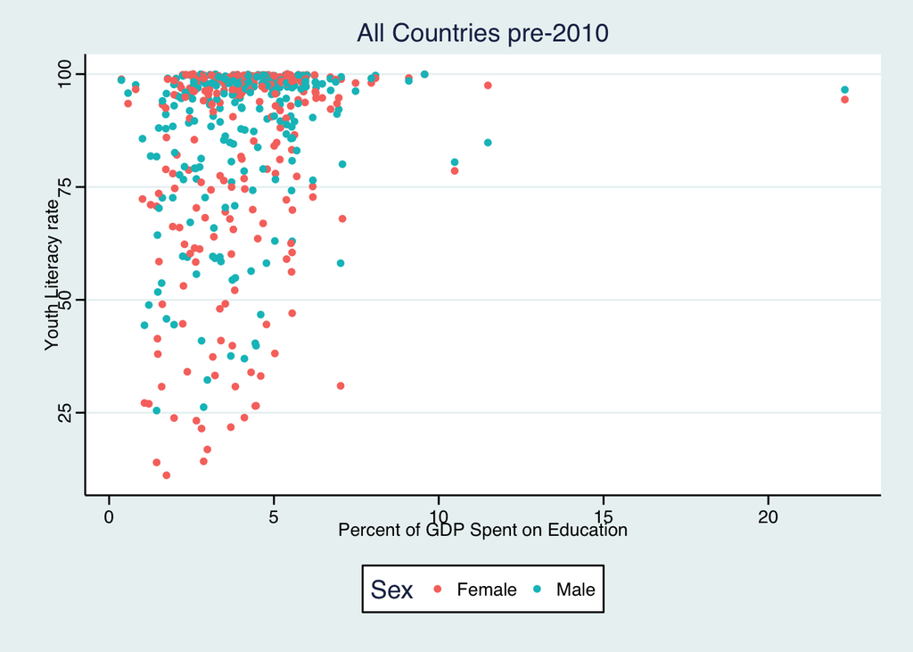

```r
source("../02 Data Wrangling/Plot1.R", echo = TRUE)
```

#### Data Wrangling set 2 (Using outer-join):

```
##
## > require(tidyr)
##
## > require(dplyr)
##
## > require(ggplot2)
##
## > require(plyr)
##
## > Table2_df <- dplyr::left_join(YL, PG, by = c("TIME_PERIOD",
## +     "REFERENCE_AREA"))
```

```
##
## > Plot2_df <- Table2_df %>% filter(SEX.x != "All genders",
## +     REFERENCE_AREA %in% c("Burkina Faso", "Mali", "Guinea", "Bangladesh",
## +         "Eg ..." ... [TRUNCATED]
##
## > ggplot() + coord_cartesian() + scale_x_continuous() +
## +     scale_y_continuous() + facet_wrap(~REFERENCE_AREA) + labs(title = "Underdeveloped and D ..." ... [TRUNCATED]
```

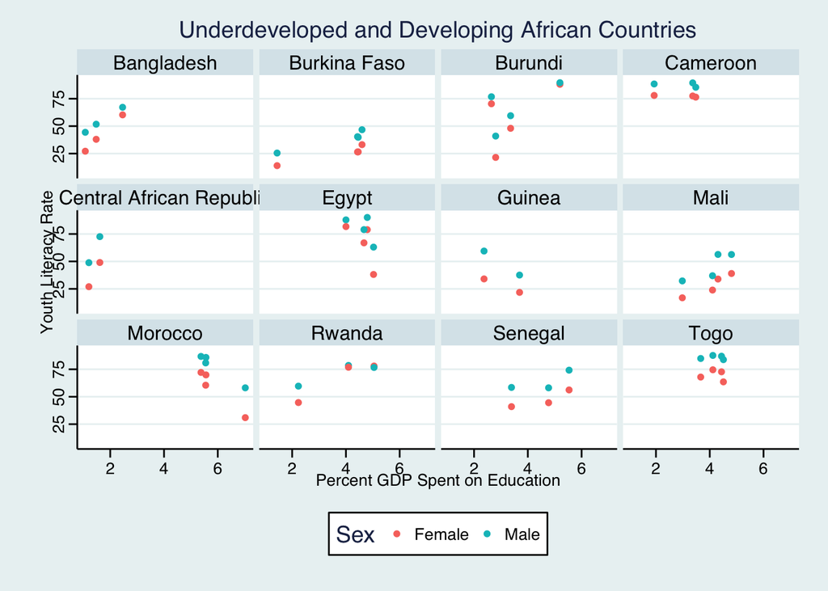

```r
source("../02 Data Wrangling/Plot2.R", echo = TRUE)
```

#### Data Wrangling set 3 (Using full-join):

Below is a visualization of a subset of the data. We thought it would be insightful to see how the variables changed over the time period between 2000 and 2012. As The faceted graph shows, there is a trickling of data points, representing countries, from the lower end of the graph to the upper end of the graph showing that literacy rates were improving through the years. It was surprising however to see that percentage of GDP spent on education seemed to play little role in the improvement of youth literacy rates over the years.

```
##
## > require(tidyr)
##
## > require(dplyr)
##
## > require(ggplot2)
##
## > require(plyr)
##
## > Table3_df <- dplyr::full_join(YL, PG, by = c("TIME_PERIOD",
## +     "REFERENCE_AREA"))
```

```
##
## > Plot3_df <- Table3_df %>% filter(TIME_PERIOD >= 2000 &
## +     TIME_PERIOD <= 2012, SEX.x == "All genders")
##
## > ggplot() + coord_cartesian() + scale_x_continuous() +
## +     scale_y_continuous() + facet_wrap(~TIME_PERIOD) + labs(title = "Literacy Rate Growth Ov ..." ... [TRUNCATED]
```

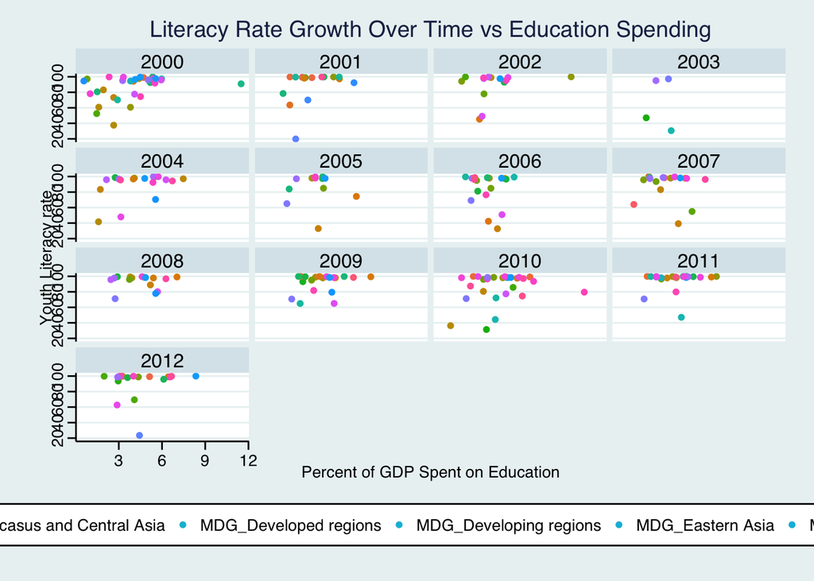

```r
source("../02 Data Wrangling/Plot3.R", echo = TRUE)
```

#### Data Wrangling set 4 :

An interesting variable we wanted to observe a little more closely was the gender variable. We assumed, specially in the developing countries, females would take a longer time to move up the literacy rates. The bar graph only represents countries with les then 50% youth literacy. As we can see from the data visualization, over time, there is much fewer male literacy rates below 50, while female literacy rates remain more prevalently under 50%.

```
##
## > require(tidyr)
##
## > require(dplyr)
##
## > require(ggplot2)
##
## > require(plyr)
##
## > require(ggthemes)
##
## > Table4_df <- dplyr::inner_join(YL, PG, by = c("TIME_PERIOD",
## +     "REFERENCE_AREA"))
```

```
##
## > Plot4_df <- Table4_df %>% filter(OBSERVATION_VALUE.x <=
## +     50, SEX.x != "All genders", TIME_PERIOD <= 2000)
##
## > ggplot() + coord_cartesian() + scale_x_continuous() +
## +     scale_y_continuous() + labs(title = "Male Vs Female Youth Literacy rates (Countries bel ..." ... [TRUNCATED]
```

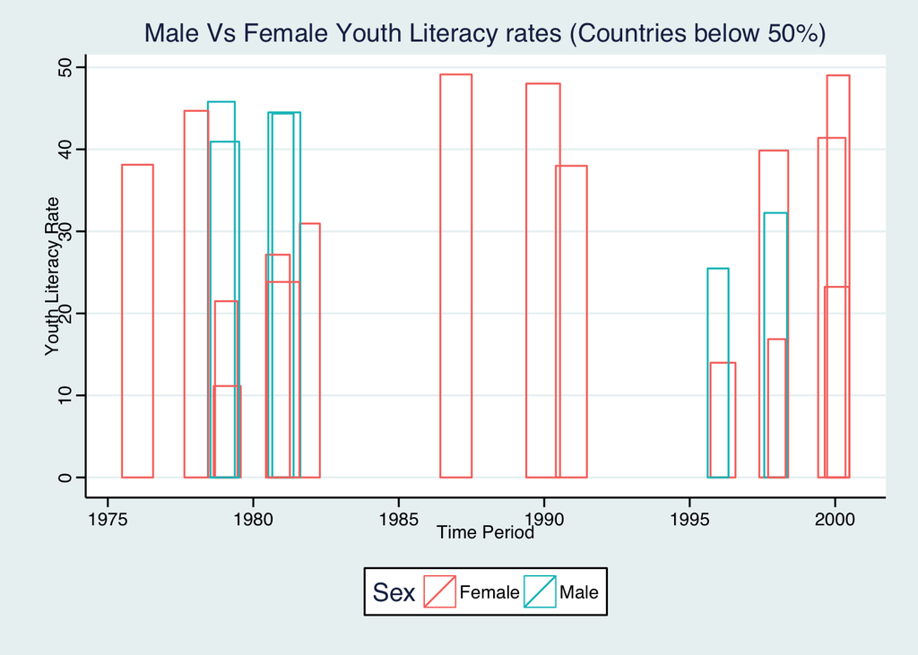

```r
source("../02 Data Wrangling/Plot4.R", echo = TRUE)
```